# NTD Event Thermal Modeling

#### Surya Dutta | Summer 2017

## Thermal Model

[figure not shown]

### Temperature-Independent Power Conservation Equations: NTD Event

$\textrm{Phonon: } C_{\textrm{Phonon}} \frac{dT_{\textrm{Phonon}}}{dt} + K_{\textrm{NTD Gold Wire}}(T_{\textrm{Phonon}}-T_{\textrm{Sink}}) - K_{\textrm{NTD Glue}} (T_{\textrm{TeO}_2} - T_{\textrm{Phonon}}) - K_{\textrm{E-P Coupling}} (T_{\textrm{Electron}} - T_{\textrm{Phonon}}) = P_{\textrm{NTD Event}}$

$\textrm{Electron: }C_{\textrm{Electron}} \frac{dT_{\textrm{Electron}}}{dt}- P_{\textrm{Electrical Power}} + K_{\textrm{E-P Coupling}} (T_{\textrm{Electron}} - T_{\textrm{Phonon}})=0$

$\textrm{Heater: }C_{\textrm{Heater}} \frac{dT_{\textrm{Heater}}}{dt}+K_{\textrm{Heater Gold Wire}}(T_{\textrm{Heater}}-T_{\textrm{Sink}})- K_{\textrm{Heater Glue}} (T_{\textrm{TeO}_2} - T_{\textrm{Heater}}) = 0$

$\textrm{Crystal: } C_{\textrm{Crystal}} \frac{dT_{\textrm{Crystal}}}{dt} + K_{\textrm{Heater Glue}}(T_{\textrm{TeO}_2}-T_{\textrm{Heater}}) + K_{\textrm{NTD Glue}} (T_{\textrm{TeO}_2} - T_{\textrm{NTD Phonon}})+ K_{\textrm{TeO}_2 \leftrightarrow \textrm{Teflon}} (T_{\textrm{TeO}_2} - T_{\textrm{Teflon}})=0$

$\textrm{Teflon: } C_{\textrm{Teflon}} \frac{dT_{\textrm{Teflon}}}{dt} + K_{\textrm{Teflon} \leftrightarrow \textrm{Sink}}(T_{\textrm{Teflon}}-T_{\textrm{Sink}}) - K_{\textrm{TeO}_2 \leftrightarrow \textrm{Teflon}} (T_{\textrm{TeO}_2} - T_{\textrm{Teflon}}) = 0$

### Adding Temperature Dependence

#### Conductance

Conductance (K) is related to temperature by a power law relation: $K(T) = K_0T^\beta$. It can also be written as the time derivative of power $\frac{dP}{dt}$, such that we can express power as $P(T)=\int^{T_2}_{T_1} K(T') dT'$, where $T_s$ is the temperature of the heat sink. Using this, we can integrate the equation to get

$$({T_2}^{\beta+1}-{T_1}^{\beta+1}) = \frac{\beta+1}{K_0} P(T)$$

#### Capacitance

Additionally, various heat capacitances also have temperature dependence based on the material. They are as follows:

$$C_{\textrm{Phonon}} = \alpha T^3 $$$$C_{\textrm{Electron}} = \alpha T $$$$C_{\textrm{Heater}} = \alpha T $$$$C_{\textrm{Crystal}} = \alpha T^3 $$$$C_{\textrm{Teflon}} = \alpha_1 T+ \alpha_2 T^3 $$

#### Electrical Feedback

[figure not shown]

Solving this circuit, we obtain (Vignati):

$$ \left[ \frac{R_L + R(T)}{R(T)} \right] V(T) - V_B + R_L c_p \frac{dV(T)}{dt} = 0 $$

The resistance of a thermistor is given by $R(T) = R_0 \exp\left(\frac{T_0}{T}\right)^\gamma$. Therefore, we modify equation 2 above and add the differential equation for $V$.

#### Putting It All Together

$\textrm{Phonon (a) : } P_{\textrm{NTD Event}} = \alpha_a {T_a}^3 \frac{dT_{a}}{dt}- \frac{K_{\textrm{0, NTD Glue}}}{\beta_1+1}({T_{d}}^{\beta_1+1} - {T_{a}}^{\beta_1+1}) - \frac{K_{\textrm{0, E-P Coupling}}}{\beta_2+1} ({T_{b}}^{\beta_2+1} - {T_{a}}^{\beta_2+1}) + \frac{K_{\textrm{0, NTD Gold Wire}}}{\beta_3+1}({T_{a}}^{\beta_3+1}-{T_{s}}^{\beta_3+1})$

$\textrm{Electron (b) : }0=\alpha_b T_b \frac{dT_{b}}{dt}- \frac{{V(T)}^2 - {V_0(T)}^2}{R_0 \exp\left(\frac{T_0}{T}\right)^\gamma} + \frac{K_{\textrm{0, E-P Coupling}}}{\beta_2+1} ({T_{b}}^{\beta_2+1} - {T_{a}}^{\beta_2+1})$

$\textrm{Heater (c) : }0=\alpha_c T_c \frac{dT_{c}}{dt}-\frac{K_{\textrm{0, Heater Glue}}}{\beta_4+1} ({T_{d}}^{\beta_4+1} - {T_{c}}^{\beta_4+1}) +\frac{K_{\textrm{0, Heater Gold Wire}}}{\beta_5+1}({T_{c}}^{\beta_5+1}-{T_{s}}^{\beta_5+1})$

$\textrm{Crystal (d) : }0 = \alpha_d {T_d}^3 \frac{dT_{d}}{dt} + \frac{K_{\textrm{0, NTD Glue}}}{\beta_1+1} ({T_{d}}^{\beta_1+1} - {T_{a}}^{\beta_1+1}) + \frac{K_{\textrm{0, Heater Glue}}}{\beta_4+1}({T_{d}}^{\beta_4+1}-{T_{c}}^{\beta_4+1}) + \frac{K_{\textrm{0, TeO}_2 \leftrightarrow \textrm{Teflon}}}{\beta_6 +1} ({T_{d}}^{\beta_6 +1} - {T_{e}}^{\beta_6 +1})$

$\textrm{Teflon (e) : } 0 = (\alpha_{e1}T_e+\alpha_{e2}{T_e}^3) \frac{dT_{e}}{dt}- \frac{K_{\textrm{0, TeO}_2 \leftrightarrow \textrm{Teflon}}}{\beta_6+1} ({T_{d}}^{\beta_6+1} - {T_{e}}^{\beta_6+1}) + \frac{K_{\textrm{0, Teflon} \leftrightarrow \textrm{Sink}}}{\beta_7+1}({T_{e}}^{\beta_7+1}-{T_{s}}^{\beta_7+1})$

$\textrm{Feedback V (f) : }0=\left[\frac{R_L + R_0 \exp\left(\frac{T_0}{T}\right)^\gamma}{R_0 \exp\left(\frac{T_0}{T}\right)^\gamma} \right] V(T) - V_B + R_L c_p \frac{dV(T)}{dt}$

Code to generate events can be found here

```python
from eventGenerator import *
```

```
Total Time: 5.0 seconds
```

```python
getConstants() #output constants at base temp
```

```
+----------------+----------+
|           Name |    Value |
+----------------+----------+
|  Capacitances  |          |
|         Phonon | 9.11E-14 |
|       Electron | 1.48E-10 |
|         Heater | 1.50E-13 |
|        Crystal | 2.47E-09 |
|         Teflon | 6.42E-09 |
|                |          |
|  Conductances  |          |
|       NTD Glue | 7.90E-09 |
|    EP Coupling | 1.50E-08 |
|       NTD Gold | 1.34E-09 |
|    Heater Glue | 4.39E-09 |
|    Heater Gold | 1.34E-09 |
| Crystal-Teflon | 5.62E-09 |
|    Teflon-Sink | 6.00E-09 |
+----------------+----------+
```

### Crystal Event

```python
getTemps('crystal')
```

```
Crystal Event
100.0% | (05:24|-1:59)
```

```
Amplitude: 0.000109941820074 K
Rise Time: 0.048s
Decay Time: 0.496s
```

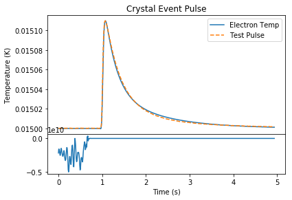

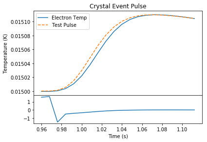

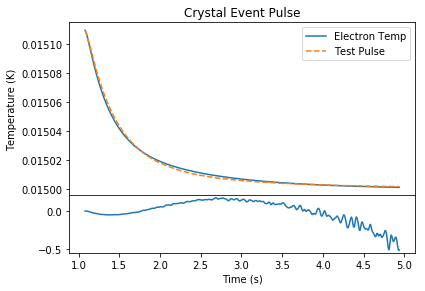

```python
import math
import pandas as pd
import numpy as np
%matplotlib inline
import matplotlib
import matplotlib.pyplot as plt
from matplotlib.pylab import *
import scipy
from scipy import signal

sampling = 8.0

#import simulated pulse
f="data/outputcrystal.csv"
crystalEventArray = np.genfromtxt(f, delimiter=',')
crystalEventArray = crystalEventArray[0::sampling,:]

#import test pulse
avg='data/testPulse.csv'
averagePulseArray = np.genfromtxt(avg,delimiter=",")
averagePulseArray = averagePulseArray[:,1]

#apply bessel filters to simulated pulse
def bessel_lowpass(cutoff, fs, order):
    nyq = 0.5 * fs
    normal_cutoff = cutoff / nyq
    b, a = signal.bessel(order, normal_cutoff, btype='low', analog=False)
    return b, a

def bessel_lowpass_filter(data, cutoff, fs, order):
    b, a = bessel_lowpass(cutoff, fs, order)
    y = signal.filtfilt(b, a, data)
    return y

cutoff = 18
samplingRate = 1.0/(sampling*dur)
order = 4

timeArray = crystalEventArray[:,0]
phononPulseArray = bessel_lowpass_filter(crystalEventArray[:,1],cutoff,samplingRate,order)
electronPulseArray = bessel_lowpass_filter(crystalEventArray[:,2],cutoff,samplingRate,order)
heaterPulseArray = bessel_lowpass_filter(crystalEventArray[:,3],cutoff,samplingRate,order)
crystalPulseArray = bessel_lowpass_filter(crystalEventArray[:,4],cutoff,samplingRate,order)
teflonPulseArray = bessel_lowpass_filter(crystalEventArray[:,5],cutoff,samplingRate,order)

#normalize test pulse amplitude
crystalAmplitude = np.amax(electronPulseArray)-s
avgAmp = np.amax(averagePulseArray) - np.amin(averagePulseArray)
normAvgPulseArray = np.multiply((crystalAmplitude/avgAmp),averagePulseArray)
normavgAmp = np.amax(normAvgPulseArray) - np.amin(normAvgPulseArray)
normAvgPulseArray = np.subtract(normAvgPulseArray,np.amin(normAvgPulseArray)-s)

#fit rise times
maxTemp = np.argmax(electronPulseArray)
maxAvgTemp = np.argmax(normAvgPulseArray)

riseArray = (zip(*np.where(np.logical_and((electronPulseArray[:maxTemp]-s)>=0.1*(crystalAmplitude),(electronPulseArray[:maxTemp]-s)<=0.9*(crystalAmplitude)))))
riseAvgArray = (zip(*np.where(np.logical_and((normAvgPulseArray[:maxAvgTemp]-s)>=0.1*(crystalAmplitude),(normAvgPulseArray[:maxAvgTemp]-s)<=0.9*(crystalAmplitude)))))

delay = 1+int((((riseAvgArray[0][0] - riseArray[0][0])+(riseAvgArray[-1][0] -  riseArray[-1][0]))/2))
timeDelay = sampling*delay*1e-3

normAvgPulseArray = normAvgPulseArray[delay:]

riseTime =  (1e3*stepSize*sampling)*len(zip(*np.where(np.logical_and((electronPulseArray[:maxTemp]-s)>=0.1*(crystalAmplitude),(electronPulseArray[:maxTemp]-s)<=0.9*(crystalAmplitude)))))
decayTime =  (1e3*stepSize*sampling)*len(zip(*np.where(np.logical_and((electronPulseArray[maxTemp:]-s)>=0.3*(crystalAmplitude),(electronPulseArray[maxTemp:]-s)<=0.9*(crystalAmplitude)))))

print "Amplitude: " + str(crystalAmplitude) + ' K'
print "Rise Time: " + str(riseTime) + 's'
print "Decay Time: " + str(decayTime) + 's'

#setup simulated pulse and average pulse parameters
t = linspace(0,5-timeDelay,int((5000/sampling)+1-delay))
fig1 = plt.figure(0)
frame1=fig1.add_axes((.1,.3,.8,.6))

start = 0
end = 618

#plotPhonon, = plt.plot(t,phononPulseArray,label='Phonon Temp')
#plotCrystal, = plt.plot(t,crystalPulseArray,label='Crystal Temp')
#plotHeater, = plt.plot(t,heaterPulseArray,label='Heater Temp')
#plotTeflon, = plt.plot(t[start:end],teflonPulseArray[start:end],label='Teflon Temp')
plotElectron, = plt.plot(t[start:end],electronPulseArray[start:end],label='Electron Temp')

plotTest, = plt.plot(t[start:end],normAvgPulseArray[start:end],'--',label='Test Pulse',)

plt.legend(handles=[plotElectron,plotTest])

plt.ylabel('Temperature (K)')
plt.title('Crystal Event Pulse')

residualArray=[]
#normalized residual function
for i in range(int((5000/sampling)+1-delay)):
    residualValue = (electronPulseArray[i]-normAvgPulseArray[i])/(electronPulseArray[i]-s)
    residualArray.append(residualValue)

frame2=fig1.add_axes((.1,.1,.8,.2))

plotResidual = plt.plot(t[start:end],residualArray[start:end])
plt.xlabel('Time (s)')

crystalFig = plt.gcf()
crystalFig.set_size_inches(6,4)
crystalFig.savefig('images/crystal_event.png',dpi=300)

fig2 = plt.figure(1)
frame3=fig2.add_axes((.1,.3,.8,.6))

start = 120
end = 140

#plotPhonon, = plt.plot(t,phononPulseArray,label='Phonon Temp')
#plotCrystal, = plt.plot(t,crystalPulseArray,label='Crystal Temp')
#plotHeater, = plt.plot(t,heaterPulseArray,label='Heater Temp')
#plotTeflon, = plt.plot(t[start:end],teflonPulseArray[start:end],label='Teflon Temp')
plotElectron, = plt.plot(t[start:end],electronPulseArray[start:end],label='Electron Temp')

plotTest, = plt.plot(t[start:end],normAvgPulseArray[start:end],'--',label='Test Pulse',)

plt.legend(handles=[plotElectron,plotTest])

plt.ylabel('Temperature (K)')
plt.title('Crystal Event Pulse')

residualArray=[]
#normalized residual function
for i in range(int((5000/sampling)+1-delay)):
    residualValue = (electronPulseArray[i]-normAvgPulseArray[i])/(electronPulseArray[i]-s)
    residualArray.append(residualValue)

frame4=fig2.add_axes((.1,.1,.8,.2))

plotResidual = plt.plot(t[start:end],residualArray[start:end])
plt.xlabel('Time (s)')

crystalFig = plt.gcf()
crystalFig.set_size_inches(6,4)
crystalFig.savefig('images/crystal_event_rise.png',dpi=300)

fig3 = plt.figure(2)
frame5=fig3.add_axes((.1,.3,.8,.6))

start = 135
end = 618

#plotPhonon, = plt.plot(t,phononPulseArray,label='Phonon Temp')
#plotCrystal, = plt.plot(t,crystalPulseArray,label='Crystal Temp')
#plotHeater, = plt.plot(t,heaterPulseArray,label='Heater Temp')
#plotTeflon, = plt.plot(t[start:end],teflonPulseArray[start:end],label='Teflon Temp')
plotElectron, = plt.plot(t[start:end],electronPulseArray[start:end],label='Electron Temp')

plotTest, = plt.plot(t[start:end],normAvgPulseArray[start:end],'--',label='Test Pulse',)

plt.legend(handles=[plotElectron,plotTest])

plt.ylabel('Temperature (K)')
plt.title('Crystal Event Pulse')

residualArray=[]
#normalized residual function
for i in range(int((5000/sampling)+1-delay)):
    residualValue = (electronPulseArray[i]-normAvgPulseArray[i])/(electronPulseArray[i]-s)
    residualArray.append(residualValue)

frame6=fig3.add_axes((.1,.1,.8,.2))

plotResidual = plt.plot(t[start:end],residualArray[start:end])
plt.xlabel('Time (s)')

crystalFig = plt.gcf()
crystalFig.set_size_inches(6,4)
crystalFig.savefig('images/crystal_event_decay.png',dpi=300)
```

### NTD Event

```python
getTemps('ntd')
```

```
NTD Event
100.0% | (05:26|-1:59)
```

```
Amplitude: 0.000692372950199 K
Rise Time: 0.032s
Decay Time: 0.04s
```

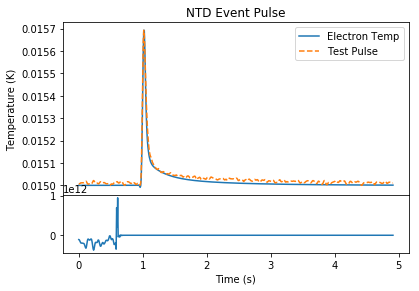

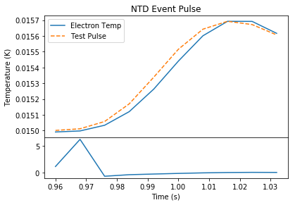

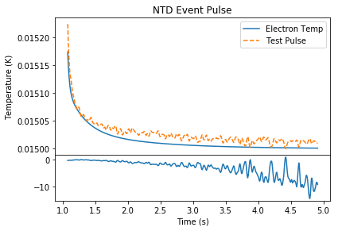

```python
#import simulated pulse
g="data/outputntd.csv"
ntdEventArray = np.genfromtxt(g, delimiter=',')
ntdEventArray = ntdEventArray[0::sampling,:]

#import test pulse
avg='data/testNTD.csv'
averagePulseArray = np.genfromtxt(avg,delimiter=",")
averagePulseArray = averagePulseArray[:,1]

timeArray = ntdEventArray[:,0]
phononPulseArray = bessel_lowpass_filter(ntdEventArray[:,1],cutoff,samplingRate,order)
electronPulseArray = bessel_lowpass_filter(ntdEventArray[:,2],cutoff,samplingRate,order)
heaterPulseArray = bessel_lowpass_filter(ntdEventArray[:,3],cutoff,samplingRate,order)
crystalPulseArray = bessel_lowpass_filter(ntdEventArray[:,4],cutoff,samplingRate,order)
teflonPulseArray = bessel_lowpass_filter(ntdEventArray[:,5],cutoff,samplingRate,order)

#normalize test pulse amplitude
ntdAmplitude = np.amax(electronPulseArray)-s
avgAmp = np.amax(averagePulseArray) - np.amin(averagePulseArray)
normAvgPulseArray = np.multiply((ntdAmplitude/avgAmp),averagePulseArray)
normavgAmp = np.amax(normAvgPulseArray) - np.amin(normAvgPulseArray)
normAvgPulseArray = np.subtract(normAvgPulseArray,np.amin(normAvgPulseArray)-s)

#fit rise times
maxTemp = np.argmax(electronPulseArray)
maxAvgTemp = np.argmax(normAvgPulseArray)

riseArray = (zip(*np.where(np.logical_and((electronPulseArray[:maxTemp]-s)>=0.1*(ntdAmplitude),(electronPulseArray[:maxTemp]-s)<=0.9*(ntdAmplitude)))))
riseAvgArray = (zip(*np.where(np.logical_and((normAvgPulseArray[:maxAvgTemp]-s)>=0.1*(ntdAmplitude),(normAvgPulseArray[:maxAvgTemp]-s)<=0.9*(ntdAmplitude)))))

delay = 1+int((((riseAvgArray[0][0] - riseArray[0][0])+(riseAvgArray[-1][0] -  riseArray[-1][0]))/2))
timeDelay = sampling*delay*1e-3

normAvgPulseArray = normAvgPulseArray[delay:]
ntdEventArray = ntdEventArray[:-delay]

riseTime =  (1e3*stepSize*sampling)*len(zip(*np.where(np.logical_and((electronPulseArray[:maxTemp]-s)>=0.1*(ntdAmplitude),(electronPulseArray[:maxTemp]-s)<=0.9*(ntdAmplitude)))))
decayTime =  (1e3*stepSize*sampling)*len(zip(*np.where(np.logical_and((electronPulseArray[maxTemp:]-s)>=0.3*(ntdAmplitude),(electronPulseArray[maxTemp:]-s)<=0.9*(ntdAmplitude)))))

print "Amplitude: " + str(ntdAmplitude) + ' K'
print "Rise Time: " + str(riseTime) + 's'
print "Decay Time: " + str(decayTime) + 's'

#setup simulated pulse and average pulse parameters
t = linspace(0,5-timeDelay,int((5000/sampling)+1-delay))
fig1 = plt.figure(0)
frame1=fig1.add_axes((.1,.3,.8,.6))

start = 0
end = 615

#plotPhonon, = plt.plot(t,phononPulseArray,label='Phonon Temp')
#plotCrystal, = plt.plot(t,crystalPulseArray,label='Crystal Temp')
#plotHeater, = plt.plot(t,heaterPulseArray,label='Heater Temp')
#plotTeflon, = plt.plot(t[start:end],teflonPulseArray[start:end],label='Teflon Temp')
plotElectron, = plt.plot(t[start:end],electronPulseArray[start:end],label='Electron Temp')

plotTest, = plt.plot(t[start:end],normAvgPulseArray[start:end],'--',label='Test Pulse',)

plt.legend(handles=[plotElectron,plotTest])

plt.ylabel('Temperature (K)')
plt.title('NTD Event Pulse')

residualArray=[]
#normalized residual function
for i in range(int((5000/sampling)+1-delay)):
    residualValue = (electronPulseArray[i]-normAvgPulseArray[i])/(electronPulseArray[i]-s)
    residualArray.append(residualValue)

frame2=fig1.add_axes((.1,.1,.8,.2))

plotResidual = plt.plot(t[start:end],residualArray[start:end])
plt.xlabel('Time (s)')

crystalFig = plt.gcf()
crystalFig.set_size_inches(6,4)
crystalFig.savefig('images/ntd_event.png',dpi=300)

fig2 = plt.figure(1)
frame3=fig2.add_axes((.1,.3,.8,.6))

start = 120
end = 130

#plotPhonon, = plt.plot(t,phononPulseArray,label='Phonon Temp')
#plotCrystal, = plt.plot(t,crystalPulseArray,label='Crystal Temp')
#plotHeater, = plt.plot(t,heaterPulseArray,label='Heater Temp')
#plotTeflon, = plt.plot(t[start:end],teflonPulseArray[start:end],label='Teflon Temp')
plotElectron, = plt.plot(t[start:end],electronPulseArray[start:end],label='Electron Temp')

plotTest, = plt.plot(t[start:end],normAvgPulseArray[start:end],'--',label='Test Pulse',)

plt.legend(handles=[plotElectron,plotTest])

plt.ylabel('Temperature (K)')
plt.title('NTD Event Pulse')

residualArray=[]
#normalized residual function
for i in range(int((5000/sampling)+1-delay)):
    residualValue = (electronPulseArray[i]-normAvgPulseArray[i])/(electronPulseArray[i]-s)
    residualArray.append(residualValue)

frame4=fig2.add_axes((.1,.1,.8,.2))

plotResidual = plt.plot(t[start:end],residualArray[start:end])
plt.xlabel('Time (s)')

crystalFig = plt.gcf()
crystalFig.set_size_inches(6,4)
crystalFig.savefig('images/ntd_event_rise.png',dpi=300)

fig3 = plt.figure(2)
frame5=fig3.add_axes((.1,.3,.8,.6))

start = 135
end = 615

#plotPhonon, = plt.plot(t,phononPulseArray,label='Phonon Temp')
#plotCrystal, = plt.plot(t,crystalPulseArray,label='Crystal Temp')
#plotHeater, = plt.plot(t,heaterPulseArray,label='Heater Temp')
#plotTeflon, = plt.plot(t[start:end],teflonPulseArray[start:end],label='Teflon Temp')
plotElectron, = plt.plot(t[start:end],electronPulseArray[start:end],label='Electron Temp')

plotTest, = plt.plot(t[start:end],normAvgPulseArray[start:end],'--',label='Test Pulse',)

plt.legend(handles=[plotElectron,plotTest])

plt.ylabel('Temperature (K)')
plt.title('NTD Event Pulse')

residualArray=[]
#normalized residual function
for i in range(int((5000/sampling)+1-delay)):
    residualValue = (electronPulseArray[i]-normAvgPulseArray[i])/(electronPulseArray[i]-s)
    residualArray.append(residualValue)

frame6=fig3.add_axes((.1,.1,.8,.2))

plotResidual = plt.plot(t[start:end],residualArray[start:end])
plt.xlabel('Time (s)')

crystalFig = plt.gcf()
crystalFig.set_size_inches(6,4)
crystalFig.savefig('images/ntd_event_decay.png',dpi=300)
```

```python
print "ntdAmp/crystalAmp: " + str(ntdAmplitude/crystalAmplitude)
```

[output not shown]

### Heater Event

```python
getTemps('heater')
```

```
Heater Event
100.0% | (05:18|-1:59)
```

```
Amplitude: 9.02055453103e-05 K
Rise Time: 0.048s
Decay Time: 0.496s
```

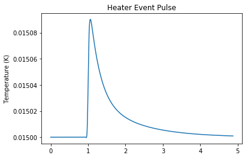

```python
#import simulated pulse
g="data/outputheater.csv"
heaterEventArray = np.genfromtxt(g, delimiter=',')
heaterEventArray = heaterEventArray[0::sampling,:]

timeArray = ntdEventArray[:,0]
phononPulseArray = bessel_lowpass_filter(heaterEventArray[:,1],cutoff,samplingRate,order)
electronPulseArray = bessel_lowpass_filter(heaterEventArray[:,2],cutoff,samplingRate,order)
heaterPulseArray = bessel_lowpass_filter(heaterEventArray[:,3],cutoff,samplingRate,order)
crystalPulseArray = bessel_lowpass_filter(heaterEventArray[:,4],cutoff,samplingRate,order)
teflonPulseArray = bessel_lowpass_filter(heaterEventArray[:,5],cutoff,samplingRate,order)

#normalize test pulse amplitude
amplitude = np.amax(electronPulseArray)-s

#fit rise times
maxTemp = np.argmax(electronPulseArray)

riseTime =  (1e3*stepSize*sampling)*len(zip(*np.where(np.logical_and((electronPulseArray[:maxTemp]-s)>=0.1*(amplitude),(electronPulseArray[:maxTemp]-s)<=0.9*(amplitude)))))
decayTime =  (1e3*stepSize*sampling)*len(zip(*np.where(np.logical_and((electronPulseArray[maxTemp:]-s)>=0.3*(amplitude),(electronPulseArray[maxTemp:]-s)<=0.9*(amplitude)))))

print "Amplitude: " + str(amplitude) + ' K'
print "Rise Time: " + str(riseTime) + 's'
print "Decay Time: " + str(decayTime) + 's'

#setup simulated pulse and average pulse parameters
t = linspace(0,5-timeDelay,int((5000/sampling)+1))
fig1 = plt.figure(0)

start = 0
end = 618

#plotPhonon, = plt.plot(t,phononPulseArray,label='Phonon Temp')
#plotCrystal, = plt.plot(t,crystalPulseArray,label='Crystal Temp')
#plotHeater, = plt.plot(t,heaterPulseArray,label='Heater Temp')
#plotTeflon, = plt.plot(t[start:end],teflonPulseArray[start:end],label='Teflon Temp')
plotElectron, = plt.plot(t[start:end],electronPulseArray[start:end],label='Electron Temp')

#plt.legend(handles=[plotElectron,plotPhonon,plotCrystal,plotHeater,plotTeflon])

plt.ylabel('Temperature (K)')
plt.title('Heater Event Pulse')


crystalFig = plt.gcf()
crystalFig.set_size_inches(6,4)
crystalFig.savefig('images/heater_event.png',dpi=300)
```

### Electron Event

```python
getTemps('electron')
```

```
Electron Event
100.0% | (06:03|-1:59)
```

```
Amplitude: 0.0009255964052 K
Rise Time: 0.032s
Decay Time: 0.04s
```

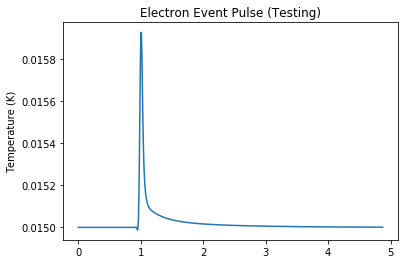

```python
#import simulated pulse
g="data/outputelectron.csv"
heaterEventArray = np.genfromtxt(g, delimiter=',')
heaterEventArray = heaterEventArray[0::sampling,:]

timeArray = heaterEventArray[:,0]
phononPulseArray = bessel_lowpass_filter(heaterEventArray[:,1],cutoff,samplingRate,order)
electronPulseArray = bessel_lowpass_filter(heaterEventArray[:,2],cutoff,samplingRate,order)
heaterPulseArray = bessel_lowpass_filter(heaterEventArray[:,3],cutoff,samplingRate,order)
crystalPulseArray = bessel_lowpass_filter(heaterEventArray[:,4],cutoff,samplingRate,order)
teflonPulseArray = bessel_lowpass_filter(heaterEventArray[:,5],cutoff,samplingRate,order)

#normalize test pulse amplitude
amplitude = np.amax(electronPulseArray)-s

#fit rise times
maxTemp = np.argmax(electronPulseArray)

riseTime =  (1e3*stepSize*sampling)*len(zip(*np.where(np.logical_and((electronPulseArray[:maxTemp]-s)>=0.1*(amplitude),(electronPulseArray[:maxTemp]-s)<=0.9*(amplitude)))))
decayTime =  (1e3*stepSize*sampling)*len(zip(*np.where(np.logical_and((electronPulseArray[maxTemp:]-s)>=0.3*(amplitude),(electronPulseArray[maxTemp:]-s)<=0.9*(amplitude)))))

print "Amplitude: " + str(amplitude) + ' K'
print "Rise Time: " + str(riseTime) + 's'
print "Decay Time: " + str(decayTime) + 's'

#setup simulated pulse and average pulse parameters
t = linspace(0,5-timeDelay,int((5000/sampling)+1))
fig1 = plt.figure(0)

start = 0
end = 618

#plotPhonon, = plt.plot(t,phononPulseArray,label='Phonon Temp')
#plotCrystal, = plt.plot(t,crystalPulseArray,label='Crystal Temp')
#plotHeater, = plt.plot(t,heaterPulseArray,label='Heater Temp')
#plotTeflon, = plt.plot(t[start:end],teflonPulseArray[start:end],label='Teflon Temp')
plotElectron, = plt.plot(t[start:end],electronPulseArray[start:end],label='Electron Temp')

#plt.legend(handles=[plotElectron,plotPhonon,plotCrystal,plotHeater,plotTeflon])

plt.ylabel('Temperature (K)')
plt.title('Electron Event Pulse (Testing)')


crystalFig = plt.gcf()
crystalFig.set_size_inches(6,4)
crystalFig.savefig('images/electron_event.png',dpi=300)
```

# Appendix

```python
# euler method in 6 dimensions
def euler(a, b, c, d, e, f, fa, fb, fc, fd, fe, ff, hs):
	a1 = fa(a, b, c, d, e, f)*hs
	b1 = fb(a, b, c, d, e, f)*hs
	c1 = fc(a, b, c, d, e, f)*hs
	d1 = fd(a, b, c, d, e, f)*hs
	e1 = fe(a, b, c, d, e, f)*hs
	f1 = ff(a, b, c, d, e, f)*hs
	#print 'diff'
	#print a1,b1,c1,d1,e1,f1
	a = a + a1
	b = b + b1
	c = c + c1
	d = d + d1
	e = e + e1
	f = f + f1
	#print 'actual'
	#print a,b,c,d,e,f
	return a,b,c,d,e,f
```